# Homework Assignment 3

Association Rules

Gunnar Sundberg - gsundberg3513@floridapoly.edu

Load the `tidyverse` package for data transformation and visualization, and the `arules` and `arulesViz` for association rules mining.

```r
library(tidyverse)
library(arules)
library(arulesViz)
```

# Problem 1

## Example 1

In this example we will define the **transaction** from a *list* object:

```r
# define lists
shopping_list <- list(
  c("flowers", "card", "soda"),
  c("toy", "flowers", "balloons", "candy"),
  c("card", "candy", "flowers"),
  c("toy", "balloons", "soda"),
  c("flowers", "card", "soda")
)
```

We now change the class of the list into a *transactions* class object (the `transactions` class represents transaction data used for mining itemsets or rules):

```r
# coerce as transaction
shopping_tr <- as(shopping_list, "transactions")
```

The apriori algorithm is used below to generate rules from our shopping list:

```r
# uses the apriori() function
shopping_rules <- apriori(shopping_tr,
                          parameter = list(support = 0.1,
                                           confidence = 0.25,
                                           minlen = 2))
```

```
Apriori

Parameter specification:
```

|  | confidence | minval | smax | arem | aval | originalSupport | maxtime | support | minlen | maxlen | target | ext |
| --- | --- | --- | --- | --- | --- | --- | --- | --- | --- | --- | --- | --- |
|  | 0.25 | 0.1 | 1 | none | FALSE | TRUE | 5 | 0.1 | 2 | 10 | rules | TRUE |

```
Algorithmic control:
```

|  | filter | tree | heap | memopt | load | sort | verbose |
| --- | --- | --- | --- | --- | --- | --- | --- |
|  | 0.1 | TRUE | TRUE | FALSE | TRUE | 2 | TRUE |

```
Absolute minimum support count: 0

set item appearances ...[0 item(s)] done [0.00s].
set transactions ...[6 item(s), 5 transaction(s)] done [0.00s].
sorting and recoding items ... [6 item(s)] done [0.00s].
creating transaction tree ... done [0.00s].
checking subsets of size 1 2 3 4 done [0.00s].
writing ... [49 rule(s)] done [0.00s].
creating S4 object  ... done [0.00s].
```

We use the `inspect()` function to check the top 3 rules based on *confidence*

```r
# inspect by confidence
inspect(head(sort(shopping_rules, by = "confidence"), 3))
```

|  | lhs |  | rhs | support | confidence | coverage | lift | count |
| --- | --- | --- | --- | --- | --- | --- | --- | --- |
| [1] | {balloons} | => | {toy} | 0.4 | 1 | 0.4 | 2.50 | 2 |
| [2] | {toy} | => | {balloons} | 0.4 | 1 | 0.4 | 2.50 | 2 |
| [3] | {candy} | => | {flowers} | 0.4 | 1 | 0.4 | 1.25 | 2 |

```r
shopping_rules %>%
  sort( . , by = "confidence") %>%
  head(3) %>%
  inspect()
```

|  | lhs |  | rhs | support | confidence | coverage | lift | count |
| --- | --- | --- | --- | --- | --- | --- | --- | --- |
| [1] | {balloons} | => | {toy} | 0.4 | 1 | 0.4 | 2.50 | 2 |
| [2] | {toy} | => | {balloons} | 0.4 | 1 | 0.4 | 2.50 | 2 |
| [3] | {candy} | => | {flowers} | 0.4 | 1 | 0.4 | 1.25 | 2 |

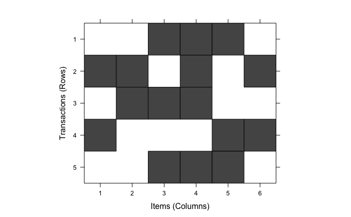

```r
image(shopping_tr)
```

## Example 2

In this example we create transactions from a data frame:

```r
## creating transactions from data.frame
students_df <- data.frame(
  age = factor(c(6, 8, NA, 9, 16)),
  grade = factor(c("A", "C", "F", NA, "C")),
  pass = c(TRUE, TRUE, FALSE, TRUE, TRUE)
)
```

Again, we *coerce* the data frame as a `transactions` object:

```r
## coerce
students_tr <- as(students_df, "transactions")
```

We can inspect this new object:

```r
# inspect
inspect(students_tr)
```

|  | items | transactionID |
| --- | --- | --- |
| [1] | {age=6,grade=A,pass} | 1 |
| [2] | {age=8,grade=C,pass} | 2 |
| [3] | {grade=F} | 3 |
| [4] | {age=9,pass} | 4 |
| [5] | {age=16,grade=C,pass} | 5 |

Below the apriori algorithm is used with its default values:

```r
students_rules <- apriori(students_tr)
```

```
Apriori

Parameter specification:
```

|  | confidence | minval | smax | arem | aval | originalSupport | maxtime | support | minlen | maxlen | target | ext |
| --- | --- | --- | --- | --- | --- | --- | --- | --- | --- | --- | --- | --- |
|  | 0.8 | 0.1 | 1 | none | FALSE | TRUE | 5 | 0.1 | 1 | 10 | rules | TRUE |

```
Algorithmic control:
```

|  | filter | tree | heap | memopt | load | sort | verbose |
| --- | --- | --- | --- | --- | --- | --- | --- |
|  | 0.1 | TRUE | TRUE | FALSE | TRUE | 2 | TRUE |

```
Absolute minimum support count: 0

set item appearances ...[0 item(s)] done [0.00s].
set transactions ...[8 item(s), 5 transaction(s)] done [0.00s].
sorting and recoding items ... [8 item(s)] done [0.00s].
creating transaction tree ... done [0.00s].
checking subsets of size 1 2 3 done [0.00s].
writing ... [18 rule(s)] done [0.00s].
creating S4 object  ... done [0.00s].
```

Let us inspect the generated rules this time based on the top 6 rules by *lift*:

```r
students_rules %>%
  sort( . , by = "lift") %>%
  head(6) %>%
  inspect()
```

|  | lhs |  | rhs | support | confidence | coverage | lift | count |
| --- | --- | --- | --- | --- | --- | --- | --- | --- |
| [1] | {grade=A} | => | {age=6} | 0.2 | 1 | 0.2 | 5.0 | 1 |
| [2] | {age=6} | => | {grade=A} | 0.2 | 1 | 0.2 | 5.0 | 1 |
| [3] | {grade=A,pass} | => | {age=6} | 0.2 | 1 | 0.2 | 5.0 | 1 |
| [4] | {age=6,pass} | => | {grade=A} | 0.2 | 1 | 0.2 | 5.0 | 1 |
| [5] | {age=8} | => | {grade=C} | 0.2 | 1 | 0.2 | 2.5 | 1 |
| [6] | {age=16} | => | {grade=C} | 0.2 | 1 | 0.2 | 2.5 | 1 |

## Example 3

First, let us create transactions from a list:

```r
publix <- list(
  c("milk", "tea", "cake"),
  c("eggs", "tea", "cold drink"),
  c("milk", "eggs", "tea", "cold drink"),
  c("eggs", "cold drink"),
  c("juice")
)
```

Convert list to transactions class:

```r
publix_tr <- as(publix, "transactions")
```

An item frequency plot can be created using the `itemFrequencyPlot()` function:

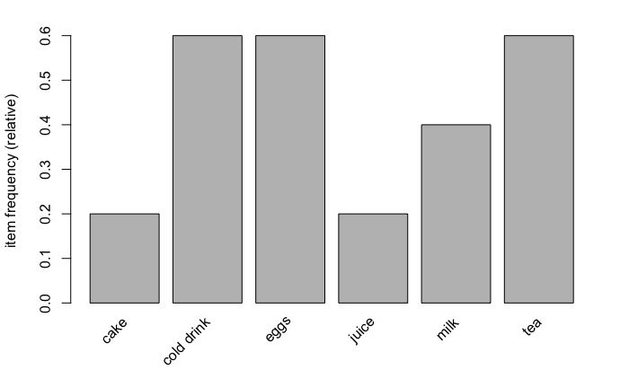

```r
itemFrequencyPlot(publix_tr)
```

Use apriori algorithm with support set to 0.4:

```r
publix_rules <- apriori(publix_tr,
                        parameter = list(support = 0.4))
```

```
Apriori

Parameter specification:
```

|  | confidence | minval | smax | arem | aval | originalSupport | maxtime | support | minlen | maxlen | target | ext |
| --- | --- | --- | --- | --- | --- | --- | --- | --- | --- | --- | --- | --- |
|  | 0.8 | 0.1 | 1 | none | FALSE | TRUE | 5 | 0.4 | 1 | 10 | rules | TRUE |

```
Algorithmic control:
```

|  | filter | tree | heap | memopt | load | sort | verbose |
| --- | --- | --- | --- | --- | --- | --- | --- |
|  | 0.1 | TRUE | TRUE | FALSE | TRUE | 2 | TRUE |

```
Absolute minimum support count: 2

set item appearances ...[0 item(s)] done [0.00s].
set transactions ...[6 item(s), 5 transaction(s)] done [0.00s].
sorting and recoding items ... [4 item(s)] done [0.00s].
creating transaction tree ... done [0.00s].
checking subsets of size 1 2 3 done [0.00s].
writing ... [5 rule(s)] done [0.00s].
creating S4 object  ... done [0.00s].
```

Inspect the rules:

```r
inspect(publix_rules)
```

|  | lhs |  | rhs | support | confidence | coverage | lift | count |
| --- | --- | --- | --- | --- | --- | --- | --- | --- |
| [1] | {milk} | => | {tea} | 0.4 | 1 | 0.4 | 1.666667 | 2 |
| [2] | {cold drink} | => | {eggs} | 0.6 | 1 | 0.6 | 1.666667 | 3 |
| [3] | {eggs} | => | {cold drink} | 0.6 | 1 | 0.6 | 1.666667 | 3 |
| [4] | {cold drink,tea} | => | {eggs} | 0.4 | 1 | 0.4 | 1.666667 | 2 |
| [5] | {eggs,tea} | => | {cold drink} | 0.4 | 1 | 0.4 | 1.666667 | 2 |

Let us visualize these rules using tools from the `arulesViz` package.

```r
plot(publix_rules, method = "graph", control = list(type = "items"),
     engine = "htmlwidget")
```

[output not shown]

[interactive chart not shown]

# Problem 2

## Example: groceries data

Michael Hahsler has authored and maintains two very useful R packages relating to association rule mining: the `arules` package and the `arulesViz` package.

The example uses the `Groceries` dataset from the R `arules` package. The `Groceries` dataset is collected from 30 days of real-world point-of-sale transactions of a grocery store.

The data contain 9835 transactions, or about 328 transactions per day. If we remove brands and just consider product type, it will give total 169 items.

- Any guesses about which types of items might be purchased together?
- Will wine and cheese be a common pairing? Bread and butter? Milk and eggs?

```r
data(Groceries)
Groceries
```

```
transactions in sparse format with
 9835 transactions (rows) and
 169 items (columns)
```

Let us find the items most commonly found in transactional data

```r
summary(Groceries)
```

```
transactions as itemMatrix in sparse format with
 9835 rows (elements/itemsets/transactions) and
 169 columns (items) and a density of 0.02609146

most frequent items:
      whole milk other vegetables       rolls/buns             soda           yogurt          (Other)
            2513             1903             1809             1715             1372            34055

element (itemset/transaction) length distribution:
sizes
   1    2    3    4    5    6    7    8    9   10   11   12   13   14   15   16   17   18   19   20   21   22   23   24   26   27   28   29   32
2159 1643 1299 1005  855  645  545  438  350  246  182  117   78   77   55   46   29   14   14    9   11    4    6    1    1    1    1    3    1

   Min. 1st Qu.  Median    Mean 3rd Qu.    Max.
  1.000   2.000   3.000   4.409   6.000  32.000

includes extended item information - examples:
```

|  | labels | level2 | level1 |
| --- | --- | --- | --- |
| 1 | frankfurter | sausage | meat and sausage |
| 2 | sausage | sausage | meat and sausage |
| 3 | liver loaf | sausage | meat and sausage |

## Generating rules

```r
grocery_rules <- apriori(Groceries,
                         parameter = list(support = 0.01, confidence = 0.5))
```

```
Apriori

Parameter specification:
```

|  | confidence | minval | smax | arem | aval | originalSupport | maxtime | support | minlen | maxlen | target | ext |
| --- | --- | --- | --- | --- | --- | --- | --- | --- | --- | --- | --- | --- |
|  | 0.5 | 0.1 | 1 | none | FALSE | TRUE | 5 | 0.01 | 1 | 10 | rules | TRUE |

```
Algorithmic control:
```

|  | filter | tree | heap | memopt | load | sort | verbose |
| --- | --- | --- | --- | --- | --- | --- | --- |
|  | 0.1 | TRUE | TRUE | FALSE | TRUE | 2 | TRUE |

```
Absolute minimum support count: 98

set item appearances ...[0 item(s)] done [0.00s].
set transactions ...[169 item(s), 9835 transaction(s)] done [0.00s].
sorting and recoding items ... [88 item(s)] done [0.00s].
creating transaction tree ... done [0.00s].
checking subsets of size 1 2 3 4 done [0.00s].
writing ... [15 rule(s)] done [0.00s].
creating S4 object  ... done [0.00s].
```

The apriori algorithm generated 15 rules with the given constraints. Let us discuss the `Parameter Specification` section of the output.

- `minval` is the minimum value of the support an itemset should satisfy to be a part of a rule.
- `smax` is the maximum support value for an itemset.
- `arem` is an Additional Rule Evaluation Parameter. In the above code we have constrained the number of rules using Support and Confidence. There are several other ways to constrain the rules using the `arem` parameter in the function.
- `aval` is a logical indicating whether to return the additional rule evaluation measure selected with `arem`.
- `originalSupport` is the traditional support value only considers both `LHS` and `RHS` items for calculating support. If you want to use only the `LHS` items for the calculation then you need to set this to `FALSE`.
- `maxtime` is the maximum amount of time allowed to check for subsets (in seconds).
- `minlen` is the minimum number of items required in the rule. The default value for `minlen` is 1. This means that rules with only one item (i.e., an empty antecedent/LHS) like `{} => {beer}` will be created. These rules mean that no matter what other items are involved, the item in the `RHS` will appear with the probability given by the rule’s confidence (which equals the support). If you want to avoid these rules then use the argument `parameter=list(minlen=2)`.
- `maxlen` is the maximum number of items that can be present in the rule.

The top 3 rules sorted by confidence are shown below

```r
grocery_rules %>%
  sort( . , by = "confidence") %>%
  head(3) %>%
  inspect()
```

|  | lhs |  | rhs | support | confidence | coverage | lift | count |
| --- | --- | --- | --- | --- | --- | --- | --- | --- |
| [1] | {citrus fruit,root vegetables} | => | {other vegetables} | 0.01037112 | 0.5862069 | 0.01769192 | 3.029608 | 102 |
| [2] | {tropical fruit,root vegetables} | => | {other vegetables} | 0.01230300 | 0.5845411 | 0.02104728 | 3.020999 | 121 |
| [3] | {curd,yogurt} | => | {whole milk} | 0.01006609 | 0.5823529 | 0.01728521 | 2.279125 | 99 |

## Limiting the number of rules

In many cases, you would like to limit the number of rules generated. For example, you can use association rules as predictors in Regression/Classification. You can generate rules with the `RHS` of the rule as your response and use the rules generated as the modelling features. In this case, you would not want to use all the rules generated as the predictors because many rules are actually subsets of bigger rules and hence you would want to eliminate them.

Below we generate rules whose `RHS` is pre-defined:

```r
wholemilk_rules <- apriori(
  data = Groceries,
  parameter = list(support = 0.001, confidence = 0.8),
  appearance = list(rhs = "whole milk")
)
```

```
Apriori

Parameter specification:
```

|  | confidence | minval | smax | arem | aval | originalSupport | maxtime | support | minlen | maxlen | target | ext |
| --- | --- | --- | --- | --- | --- | --- | --- | --- | --- | --- | --- | --- |
|  | 0.8 | 0.1 | 1 | none | FALSE | TRUE | 5 | 0.001 | 1 | 10 | rules | TRUE |

```
Algorithmic control:
```

|  | filter | tree | heap | memopt | load | sort | verbose |
| --- | --- | --- | --- | --- | --- | --- | --- |
|  | 0.1 | TRUE | TRUE | FALSE | TRUE | 2 | TRUE |

```
Absolute minimum support count: 9

set item appearances ...[1 item(s)] done [0.00s].
set transactions ...[169 item(s), 9835 transaction(s)] done [0.00s].
sorting and recoding items ... [157 item(s)] done [0.00s].
creating transaction tree ... done [0.00s].
checking subsets of size 1 2 3 4 5 6 done [0.01s].
writing ... [252 rule(s)] done [0.00s].
creating S4 object  ... done [0.00s].
```

Check the top 5 rules generated in this case:

```r
wholemilk_rules %>%
  sort( . , by = "lift") %>%
  head(5) %>%
  inspect()
```

|  | lhs |  | rhs | support | confidence | coverage | lift | count |
| --- | --- | --- | --- | --- | --- | --- | --- | --- |
| [1] | {rice,sugar} | => | {whole milk} | 0.001220132 | 1 | 0.001220132 | 3.913649 | 12 |
| [2] | {canned fish,hygiene articles} | => | {whole milk} | 0.001118454 | 1 | 0.001118454 | 3.913649 | 11 |
| [3] | {root vegetables,butter,rice} | => | {whole milk} | 0.001016777 | 1 | 0.001016777 | 3.913649 | 10 |
| [4] | {root vegetables,whipped/sour cream,flour} | => | {whole milk} | 0.001728521 | 1 | 0.001728521 | 3.913649 | 17 |
| [5] | {butter,soft cheese,domestic eggs} | => | {whole milk} | 0.001016777 | 1 | 0.001016777 | 3.913649 | 10 |

If you want to get stronger rules, you have to increase the `confidence`. If you want lengthier rules increase the `maxlen` parameter.

## From Data Frame to Transactional Data

The `AdultUCI` dataset bundled with `arules` package is used below as illustration.

```r
data("AdultUCI")
class(AdultUCI)
```

```
[1] "data.frame"
```

Notice that some of the columns are numeric:

```r
head(AdultUCI)
```

|  | age | workclass | fnlwgt | education | education-num | marital-status | occupation | relationship | race | sex | capital-gain | capital-loss | hours-per-week | native-country | income |
| --- | --- | --- | --- | --- | --- | --- | --- | --- | --- | --- | --- | --- | --- | --- | --- |
| 1 | 39 | State-gov | 77516 | Bachelors | 13 | Never-married | Adm-clerical | Not-in-family | White | Male | 2174 | 0 | 40 | United-States | small |
| 2 | 50 | Self-emp-not-inc | 83311 | Bachelors | 13 | Married-civ-spouse | Exec-managerial | Husband | White | Male | 0 | 0 | 13 | United-States | small |
| 3 | 38 | Private | 215646 | HS-grad | 9 | Divorced | Handlers-cleaners | Not-in-family | White | Male | 0 | 0 | 40 | United-States | small |
| 4 | 53 | Private | 234721 | 11th | 7 | Married-civ-spouse | Handlers-cleaners | Husband | Black | Male | 0 | 0 | 40 | United-States | small |
| 5 | 28 | Private | 338409 | Bachelors | 13 | Married-civ-spouse | Prof-specialty | Wife | Black | Female | 0 | 0 | 40 | Cuba | small |
| 6 | 37 | Private | 284582 | Masters | 14 | Married-civ-spouse | Exec-managerial | Wife | White | Female | 0 | 0 | 40 | United-States | small |

Each transaction of a *transactional dataset* contains the list of items involved in that transaction. When we convert the dataframe into a transactional dataset, each row of this dataframe will become a transaction. Each column will become an item. But if the value of a column is numeric, it cannot be used as the column can take infinite values. So before converting the dataframe into a transactional dataset, we must ensure that we convert each column into a **factor** or a logical to ensure that the column takes values only from a fixed set.

```r
adult_factor <- map_df(AdultUCI, as.factor)
```

```r
adult_factor
```

| age | workclass | fnlwgt | education | education-num | marital-status | occupation | relationship | race | sex | capital-gain | capital-loss | hours-per-week | native-country | income |
| --- | --- | --- | --- | --- | --- | --- | --- | --- | --- | --- | --- | --- | --- | --- |
| 39 | State-gov | 77516 | Bachelors | 13 | Never-married | Adm-clerical | Not-in-family | White | Male | 2174 | 0 | 40 | United-States | small |
| 50 | Self-emp-not-inc | 83311 | Bachelors | 13 | Married-civ-spouse | Exec-managerial | Husband | White | Male | 0 | 0 | 13 | United-States | small |
| 38 | Private | 215646 | HS-grad | 9 | Divorced | Handlers-cleaners | Not-in-family | White | Male | 0 | 0 | 40 | United-States | small |
| 53 | Private | 234721 | 11th | 7 | Married-civ-spouse | Handlers-cleaners | Husband | Black | Male | 0 | 0 | 40 | United-States | small |
| 28 | Private | 338409 | Bachelors | 13 | Married-civ-spouse | Prof-specialty | Wife | Black | Female | 0 | 0 | 40 | Cuba | small |
| 37 | Private | 284582 | Masters | 14 | Married-civ-spouse | Exec-managerial | Wife | White | Female | 0 | 0 | 40 | United-States | small |
| 49 | Private | 160187 | 9th | 5 | Married-spouse-absent | Other-service | Not-in-family | Black | Female | 0 | 0 | 16 | Jamaica | small |
| 52 | Self-emp-not-inc | 209642 | HS-grad | 9 | Married-civ-spouse | Exec-managerial | Husband | White | Male | 0 | 0 | 45 | United-States | large |
| 31 | Private | 45781 | Masters | 14 | Never-married | Prof-specialty | Not-in-family | White | Female | 14084 | 0 | 50 | United-States | large |
| 42 | Private | 159449 | Bachelors | 13 | Married-civ-spouse | Exec-managerial | Husband | White | Male | 5178 | 0 | 40 | United-States | large |

[output cut: 990 more lines]

Now we convert the `adult_factor` dataframe into a transactional dataset

```r
adult_tr <- as(adult_factor, "transactions")
```

Let us inspect this transactional dataset

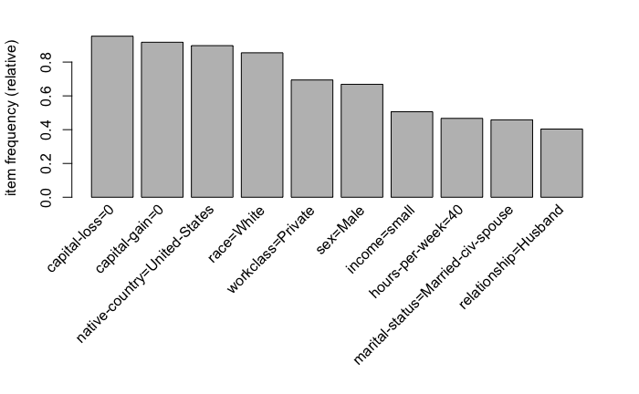

```r
itemFrequencyPlot(adult_tr, topN = 10)
```

and finally we create some rules from this dataset:

```r
adult_rules <- apriori(adult_tr,
                       parameter = list(support = 0.001, minlen = 2),
                       appearance = list(rhs = "income=small"))
```

```
Apriori

Parameter specification:
```

|  | confidence | minval | smax | arem | aval | originalSupport | maxtime | support | minlen | maxlen | target | ext |
| --- | --- | --- | --- | --- | --- | --- | --- | --- | --- | --- | --- | --- |
|  | 0.8 | 0.1 | 1 | none | FALSE | TRUE | 5 | 0.001 | 2 | 10 | rules | TRUE |

```
Algorithmic control:
```

|  | filter | tree | heap | memopt | load | sort | verbose |
| --- | --- | --- | --- | --- | --- | --- | --- |
|  | 0.1 | TRUE | TRUE | FALSE | TRUE | 2 | TRUE |

```
Absolute minimum support count: 48

set item appearances ...[1 item(s)] done [0.00s].
set transactions ...[29032 item(s), 48842 transaction(s)] done [0.19s].
sorting and recoding items ... [239 item(s)] done [0.01s].
creating transaction tree ... done [0.03s].
checking subsets of size 1 2 3 4 5 6 7 8 9 10
```

```
Mining stopped (maxlen reached). Only patterns up to a length of 10 returned!
```

```
 done [4.37s].
writing ... [203 rule(s)] done [0.05s].
creating S4 object  ... done [0.15s].
```

The top 4 rules organized by lift are shown below:

```r
adult_rules %>%
  sort( . , by = "lift") %>%
  head(4) %>%
  inspect
```

```
    lhs                               rhs                support confidence    coverage     lift count
[1] {age=43,
     marital-status=Divorced,
     race=White,
     capital-gain=0,
     capital-loss=0,
     hours-per-week=40,
     native-country=United-States} => {income=small} 0.001310348  0.8533333 0.001535564 1.686024    64
[2] {age=43,
     marital-status=Divorced,
     race=White,
     capital-gain=0,
     capital-loss=0,
     hours-per-week=40}            => {income=small} 0.001371770  0.8375000 0.001637935 1.654740    67
[3] {education=9th,
     occupation=Other-service,
     sex=Male,
     capital-loss=0}               => {income=small} 0.001146554  0.8358209 0.001371770 1.651422    56
[4] {education-num=5,
     occupation=Other-service,
     sex=Male,
     capital-loss=0}               => {income=small} 0.001146554  0.8358209 0.001371770 1.651422    56
```

# Problem 3

This problem explores association rules mining for music recommendation using the `last.fm` data:

```r
# notice we are using read.csv() here
lastfm <- read.csv("https://raw.githubusercontent.com/reisanar/datasets/master/lastfm.csv")
```

- Make all variables in the dataframe above an attribute of classs `factor` (categorical variable):

```r
lastfm <- map_df(lastfm, as.factor)
```

```r
# coerce it as a dataframe (instead of a tibble)
lastfm <- as.data.frame(lastfm)
```

- Here’s a random sample of the rows in the data frame:

```r
set.seed(217)
sample_n(lastfm, size = 7)
```

| user | artist | sex | country |
| --- | --- | --- | --- |
| 7407 | madlib | m | United States |
| 3580 | patrick wolf | m | United Kingdom |
| 13584 | alice in chains | m | Serbia |
| 14151 | bloc party | m | United Kingdom |
| 5092 | aphex twin | m | Australia |
| 14758 | the chemical brothers | m | United Kingdom |
| 15282 | madonna | f | Ukraine |

The variable `country` refers to the location of the `user`.

1. Find the top 10 most popular artists based on their appearance in the data set (regardless of the country). **HINT:** use tools from the `dplyr` (part of the `tidyverse`) to group by `artist`, count their appearances (for example using `count()`) and then display the top 10.

```r
lastfm %>%
  group_by(artist) %>%
  count(sort = TRUE) %>%
  top_n(10)
```

| artist | n |
| --- | --- |
| radiohead | 2704 |
| the beatles | 2668 |
| coldplay | 2378 |
| red hot chili peppers | 1786 |
| muse | 1711 |
| metallica | 1670 |
| pink floyd | 1574 |
| linkin park | 1473 |
| nirvana | 1473 |
| the killers | 1473 |

[output cut: 990 more lines]

> Looks like the top 10 is completely dominated by rock bands, including my favorite band (Radiohead), in the top spot.
2. How would you find the number of different users in this dataset? (If you use the `summarise()` function, add the argument `.groups = "drop"` to avoid the warning message. Example `summarise(n = n(), .groups = "drop")` )

```r
lastfm %>%
  distinct(user) %>%
  count()
```

| n |
| --- |
| 15000 |

> Using `dplyr`, we are able to see that there are 15,000 users in the dataset.
3. How many different artists are in this dataset?

```r
lastfm %>%
  distinct(artist) %>%
  count()
```

| n |
| --- |
| 1004 |

> Using `dplyr`, we are able to see that there are 1,004 artists in the dataset.

**Pre-processing**

- Let us create a list of users where every element in the list contains all the artists a user listens to.
- We split the data in the vector `x` into groups defined in vector `f` in *supermarket terminology*, think of users as shoppers and artists as items bought

```r
# this is a large list
playlist <- base::split(x = lastfm[ , "artist"], f = lastfm$user)
```

- You can then see the artists included in the first two users (user ID 1 and 3)

```r
playlist[1:2]
```

```
$`1`
 [1] red hot chili peppers   the black dahlia murder goldfrapp               dropkick murphys        le tigre                schandmaul
 [7] edguy                   jack johnson            eluveitie               the killers             judas priest            rob zombie
[13] john mayer              the who                 guano apes              the rolling stones
1004 Levels: ...and you will know us by the trail of dead [unknown] 2pac 3 doors down 30 seconds to mars 311 36 crazyfists 44 50 cent ... zero 7

$`3`
 [1] devendra banhart    boards of canada    cocorosie           aphex twin          animal collective   atmosphere          joanna newsom
 [8] air                 portishead          massive attack      broken social scene arcade fire         plaid               prefuse 73
[15] m83                 the flashbulb       pavement            goldfrapp           amon tobin          sage francis        four tet
[22] max richter         autechre            radiohead           neutral milk hotel  beastie boys        aesop rock          mf doom
[29] the books
1004 Levels: ...and you will know us by the trail of dead [unknown] 2pac 3 doors down 30 seconds to mars 311 36 crazyfists 44 50 cent ... zero 7
```

- Since an artist may be mentioned by the same user more than once, it is important to remove artist duplicates:

```r
## remove artist duplicates
playlist_clean <- map(playlist, unique)
```

4. Change the class of the `playlist_clean` object to a transactions class, and create an item frequency plot using `itemFrequencyPlot()` with the option `support = 0.08`

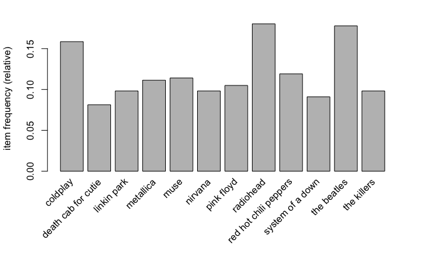

```r
# code here
playlist_tr <- as(playlist_clean, "transactions")
itemFrequencyPlot(playlist_tr, support = 0.08)
```

> Item frequency is what we would expect given our top 10 artists analysis earlier. It seems like Radiohead, Coldplay, and the Beatles are in a class of their own.
5. Use the apriori algorithm with `support = 0.01` and `confidence = 0.5`. Inspect the rules, and list the top 10 rules by lift.

```r
playlist_rules <- apriori(data = playlist_tr,
                          parameter = list(support = 0.01, confidence = 0.5))
```

```
Apriori

Parameter specification:
```

|  | confidence | minval | smax | arem | aval | originalSupport | maxtime | support | minlen | maxlen | target | ext |
| --- | --- | --- | --- | --- | --- | --- | --- | --- | --- | --- | --- | --- |
|  | 0.5 | 0.1 | 1 | none | FALSE | TRUE | 5 | 0.01 | 1 | 10 | rules | TRUE |

```
Algorithmic control:
```

|  | filter | tree | heap | memopt | load | sort | verbose |
| --- | --- | --- | --- | --- | --- | --- | --- |
|  | 0.1 | TRUE | TRUE | FALSE | TRUE | 2 | TRUE |

```
Absolute minimum support count: 150

set item appearances ...[0 item(s)] done [0.00s].
set transactions ...[1004 item(s), 15000 transaction(s)] done [0.05s].
sorting and recoding items ... [655 item(s)] done [0.01s].
creating transaction tree ... done [0.01s].
checking subsets of size 1 2 3 4 done [0.03s].
writing ... [50 rule(s)] done [0.00s].
creating S4 object  ... done [0.00s].
```

```r
# Top 10 rules by lift
playlist_rules %>%
  sort( . , by = "lift") %>%
  head(10) %>%
  inspect
```

|  | lhs |  | rhs | support | confidence | coverage | lift | count |
| --- | --- | --- | --- | --- | --- | --- | --- | --- |
| [1] | {the pussycat dolls} | => | {rihanna} | 0.01040000 | 0.5777778 | 0.01800000 | 13.415893 | 156 |
| [2] | {t.i.} | => | {kanye west} | 0.01040000 | 0.5672727 | 0.01833333 | 8.854413 | 156 |
| [3] | {judas priest} | => | {iron maiden} | 0.01353333 | 0.5075000 | 0.02666667 | 8.562992 | 203 |
| [4] | {sonata arctica} | => | {nightwish} | 0.01346667 | 0.5101010 | 0.02640000 | 8.236292 | 202 |
| [5] | {pink floyd,the doors} | => | {led zeppelin} | 0.01066667 | 0.5387205 | 0.01980000 | 6.802027 | 160 |
| [6] | {led zeppelin,the doors} | => | {pink floyd} | 0.01066667 | 0.5970149 | 0.01786667 | 5.689469 | 160 |
| [7] | {megadeth} | => | {metallica} | 0.01626667 | 0.5281385 | 0.03080000 | 4.743759 | 244 |
| [8] | {placebo,radiohead} | => | {muse} | 0.01366667 | 0.5137845 | 0.02660000 | 4.504247 | 205 |
| [9] | {oasis,the killers} | => | {coldplay} | 0.01113333 | 0.6626984 | 0.01680000 | 4.180183 | 167 |
| [10] | {keane} | => | {coldplay} | 0.02226667 | 0.6374046 | 0.03493333 | 4.020634 | 334 |

> Fascinating results here. This looks a bit like recommendations if you were to go on an artist’s page on Spotify. Not many surprises here, as the genres and time periods are closely related in the rules we came up with.
6. Use `apriori()` again to generate rules where RHS is `"death cab for cutie"` (copy this, so that you use the correct spelling). Use `support = 0.01` and `confidence = 0.2`. Inspect the top 6 rules (by confidence) and comment on your results.

```r
cutie_rules <- apriori(playlist_tr,
        parameter = list(support = 0.01, confidence = 0.2),
        appearance = list(rhs = "death cab for cutie")) %>%
        sort( . , by = "confidence")
```

```
Apriori

Parameter specification:
```

|  | confidence | minval | smax | arem | aval | originalSupport | maxtime | support | minlen | maxlen | target | ext |
| --- | --- | --- | --- | --- | --- | --- | --- | --- | --- | --- | --- | --- |
|  | 0.2 | 0.1 | 1 | none | FALSE | TRUE | 5 | 0.01 | 1 | 10 | rules | TRUE |

```
Algorithmic control:
```

|  | filter | tree | heap | memopt | load | sort | verbose |
| --- | --- | --- | --- | --- | --- | --- | --- |
|  | 0.1 | TRUE | TRUE | FALSE | TRUE | 2 | TRUE |

```
Absolute minimum support count: 150

set item appearances ...[1 item(s)] done [0.00s].
set transactions ...[1004 item(s), 15000 transaction(s)] done [0.06s].
sorting and recoding items ... [655 item(s)] done [0.01s].
creating transaction tree ... done [0.01s].
checking subsets of size 1 2 3 4 done [0.02s].
writing ... [24 rule(s)] done [0.00s].
creating S4 object  ... done [0.00s].
```

```r
cutie_rules %>%
  head(6) %>%
  inspect
```

|  | lhs |  | rhs | support | confidence | coverage | lift | count |
| --- | --- | --- | --- | --- | --- | --- | --- | --- |
| [1] | {the postal service} | => | {death cab for cutie} | 0.01533333 | 0.4693878 | 0.03266667 | 5.771161 | 230 |
| [2] | {radiohead,the shins} | => | {death cab for cutie} | 0.01006667 | 0.4441176 | 0.02266667 | 5.460463 | 151 |
| [3] | {the decemberists} | => | {death cab for cutie} | 0.01346667 | 0.4234801 | 0.03180000 | 5.206722 | 202 |
| [4] | {broken social scene} | => | {death cab for cutie} | 0.01146667 | 0.4164649 | 0.02753333 | 5.120470 | 172 |
| [5] | {the shins} | => | {death cab for cutie} | 0.02000000 | 0.4048583 | 0.04940000 | 4.977766 | 300 |
| [6] | {bright eyes} | => | {death cab for cutie} | 0.01520000 | 0.4021164 | 0.03780000 | 4.944054 | 228 |

> The Postal Service is a side project of Death Cab for Cutie’s lead singer. It makes sense that listening to the Postal Service is an indication that you may listen to Death Cab for Cutie. I would’ve guessed the Shins and the Decemberists, but Radiohead with the Shins being an indication of Death Cab for Cutie is an interesting find.
7. Create a network visualization of the set of rules created for Death Cab For Cutie

```r
plot(cutie_rules, method = "graph", control = list(type = "items"),
     engine = "htmlwidget")
```

```
Unknown control parameters: type
```

[output not shown]

[interactive chart not shown]

> This network graph is very helpful in visualizing the rules.
8. Use `apriori()` again to generate rules where RHS is `"coldplay"` (copy this, so that you use the correct spelling). Use `support = 0.002` and `minlen = 3`. Inspect the top 6 rules (by lift) and comment on your results.

```r
apriori(playlist_tr,
        parameter = list(support = 0.002, minlen = 3),
        appearance = list(rhs = "coldplay")) %>%
        sort( . , by = "lift") %>%
        head(6) %>%
        inspect
```

```
Apriori

Parameter specification:
```

|  | confidence | minval | smax | arem | aval | originalSupport | maxtime | support | minlen | maxlen | target | ext |
| --- | --- | --- | --- | --- | --- | --- | --- | --- | --- | --- | --- | --- |
|  | 0.8 | 0.1 | 1 | none | FALSE | TRUE | 5 | 0.002 | 3 | 10 | rules | TRUE |

```
Algorithmic control:
```

|  | filter | tree | heap | memopt | load | sort | verbose |
| --- | --- | --- | --- | --- | --- | --- | --- |
|  | 0.1 | TRUE | TRUE | FALSE | TRUE | 2 | TRUE |

```
Absolute minimum support count: 30

set item appearances ...[1 item(s)] done [0.00s].
set transactions ...[1004 item(s), 15000 transaction(s)] done [0.05s].
sorting and recoding items ... [1004 item(s)] done [0.01s].
creating transaction tree ... done [0.01s].
checking subsets of size 1 2 3 4 5 6 done [0.25s].
writing ... [72 rule(s)] done [0.02s].
creating S4 object  ... done [0.01s].
```

|  | lhs |  | rhs | support | confidence | coverage | lift | count |
| --- | --- | --- | --- | --- | --- | --- | --- | --- |
| [1] | {radiohead,snow patrol,travis} | => | {coldplay} | 0.002200000 | 0.9428571 | 0.002333333 | 5.947375 | 33 |
| [2] | {kaiser chiefs,oasis,the killers,the kooks} | => | {coldplay} | 0.002200000 | 0.9166667 | 0.002400000 | 5.782170 | 33 |
| [3] | {kaiser chiefs,keane,oasis} | => | {coldplay} | 0.002133333 | 0.9142857 | 0.002333333 | 5.767151 | 32 |
| [4] | {james blunt,keane,snow patrol} | => | {coldplay} | 0.002000000 | 0.9090909 | 0.002200000 | 5.734383 | 30 |
| [5] | {bloc party,oasis,snow patrol} | => | {coldplay} | 0.002000000 | 0.9090909 | 0.002200000 | 5.734383 | 30 |
| [6] | {death cab for cutie,oasis,radiohead,the strokes} | => | {coldplay} | 0.002000000 | 0.9090909 | 0.002200000 | 5.734383 | 30 |

> Looks like a fairly diverse set of people enjoy Coldplay. Although these are all bands that enjoyed their prime in the 90’s and 2000’s (just like Coldplay), the rock subgenres are fairly different. This was a great assignment.